# Problem Statement

## Description

The advent of e-news, or electronic news, portals has offered us a great opportunity to quickly get updates on the day-to-day events occurring globally. The information on these portals is retrieved electronically from online databases, processed using a variety of software, and then transmitted to the users. There are multiple advantages of transmitting news electronically, like faster access to the content and the ability to utilize different technologies such as audio, graphics, video, and other interactive elements that are either not being used or aren’t common yet in traditional newspapers.

E-news Express, an online news portal, aims to expand its business by acquiring new subscribers. With every visitor to the website taking certain actions based on their interest, the company plans to analyze these actions to understand user interests and determine how to drive better engagement. The executives at E-news Express believe that there has been a decline in new monthly subscribers compared to the past year because the current webpage is not designed well enough in terms of the outline & recommended content to keep customers engaged long enough to decide to subscribe.

[Companies often analyze user responses to two variants of a product to decide which of the two variants is more effective. This experimental technique, known as A/B testing, is used to determine whether a new feature attracts users based on a chosen metric.]

## Objective

The design team of the company has researched and created a new landing page that has a new outline & more relevant content compared to the old page. To test the effectiveness of the new landing page in gathering new subscribers, the Data Science team experimented by randomly selecting 100 users and dividing them equally into two groups. The existing landing page was served to the first group (control group) and the new landing page to the second group (treatment group). Data regarding the interaction of users in both groups with the two versions of the landing page was collected. Being a data scientist in E-news Express, you have been asked to explore the data and perform a statistical analysis (at a significance level of 5%) to determine the effectiveness of the new landing page in gathering new subscribers for the news portal by answering the following questions:

1. Do the users spend more time on the new landing page than on the existing landing page?
2. Is the conversion rate (the proportion of users who visit the landing page and get converted) for the new page greater than the conversion rate for the old page?
3. Does the converted status depend on the preferred language?
4. Is the time spent on the new page the same for the different language users?

## Data Dictionary

The data contains information regarding the interaction of users in both groups with the two versions of the landing page.

1. **user_id** - Unique user ID of the person visiting the website
2. **group** - Whether the user belongs to the first group (control) or the second group (treatment)
3. **landing_page** - Whether the landing page is new or old
4. **time_spent_on_the_page** - Time (in minutes) spent by the user on the landing page converted - Whether the user gets converted to a subscriber of the news portal or not
5. **language_preferred** - language chosen by the user to view the landing page

# Imports

```python
import pandas as pd
import numpy as np
import matplotlib.pyplot as plt
import seaborn as sns
import missingno as msno
from scipy import stats


# Using statsmodels.stats.proportion.proportions_ztest
from statsmodels.stats.proportion import proportions_ztest
from scipy.stats import chi2_contingency

import warnings
```

```python
plt.rcParams['figure.figsize'] = [10, 6]  # width=10, height=6
plt.rcParams['figure.dpi'] = 100  # default is usually 72a
sns.set_palette('pastel')
```

```python
warnings.filterwarnings('ignore')
```

# Data Load

```python
df = pd.read_csv('abtest.csv')
df_original = df.copy()
```

# EDA

## Data Background

```python
# Data Shape
print("Data Shape:")
print(df.shape)
```

```
Data Shape:
(100, 6)
```

```python
# Memory usage
print("\nMemory Usage:")
memory_usage = df.memory_usage(deep=True).sum() / 1e6
print(f"{memory_usage:.2f} MB")
```

```
Memory Usage:
0.03 MB
```

```python
# First few records
print("\nFirst Few Records:")
df.head()
```

```
First Few Records:
```

|  | user_id | group | landing_page | time_spent_on_the_page | converted | language_preferred |
| --- | --- | --- | --- | --- | --- | --- |
| 0 | 546592 | control | old | 3.48 | no | Spanish |
| 1 | 546468 | treatment | new | 7.13 | yes | English |
| 2 | 546462 | treatment | new | 4.40 | no | Spanish |
| 3 | 546567 | control | old | 3.02 | no | French |
| 4 | 546459 | treatment | new | 4.75 | yes | Spanish |

```python
print("Columns Summary:")

summary = pd.DataFrame({
    "Column": df.columns,
    "Dtype": df.dtypes.values,
    "Missing": df.isnull().sum().values,
    "Unique": df.nunique().values
})
summary
```

```
Columns Summary:
```

|  | Column | Dtype | Missing | Unique |
| --- | --- | --- | --- | --- |
| 0 | user_id | int64 | 0 | 100 |
| 1 | group | object | 0 | 2 |
| 2 | landing_page | object | 0 | 2 |
| 3 | time_spent_on_the_page | float64 | 0 | 94 |
| 4 | converted | object | 0 | 2 |
| 5 | language_preferred | object | 0 | 3 |

🔍 **Observations**:

- There are no missing values
- user_id is nominal attribute with all unique values
- most of column seems to be categorical with few categories
  - There are 4 categorical columns
  - There is 1 numerical column
  - There is 1 nominal column

**Descriptive Statistics**

```python
*num_cols, = df.select_dtypes(include=['number']).columns
*cat_cols, = df.select_dtypes(include=['object']).columns

print(f"Number of numerical columns: {len(num_cols)}")
print(f"Number of categorical columns: {len(cat_cols)}")

print(f"Numerical columns: {num_cols}")
print(f"Categorical columns: {cat_cols}")
```

```
Number of numerical columns: 2
Number of categorical columns: 4
Numerical columns: ['user_id', 'time_spent_on_the_page']
Categorical columns: ['group', 'landing_page', 'converted', 'language_preferred']
```

```python
# as user id is nominal col so ignoring it
num_cols.remove('user_id')
```

```python
# Numerical Columns Stats Summary
num_stats_summary = df[num_cols].describe().T
num_stats_summary['skewness'] = df[num_cols].skew()
num_stats_summary['kurtosis'] = df[num_cols].kurt()
num_stats_summary.T
```

|  | time_spent_on_the_page |
| --- | --- |
| count | 100.000000 |
| mean | 5.377800 |
| std | 2.378166 |
| min | 0.190000 |
| 25% | 3.880000 |
| 50% | 5.415000 |
| 75% | 7.022500 |
| max | 10.710000 |
| skewness | -0.149480 |
| kurtosis | -0.249984 |

```python
# Categorical Columns Stats Summary
cat_stats_summary = df[cat_cols].describe().T

# Create a dictionary to store value counts for each column
value_counts_dict = {}
for col in cat_cols:
    # Get the percentage for the most frequent value (matching the 'top' value)
    top_value = cat_stats_summary.loc[col, 'top']
    normalized_count = df[col].value_counts(normalize=True)[top_value] * 100
    value_counts_dict[col] = normalized_count

# Add the normalized counts as a new column
cat_stats_summary['top_freq_percentage'] = pd.Series(value_counts_dict)
cat_stats_summary
```

|  | count | unique | top | freq | top_freq_percentage |
| --- | --- | --- | --- | --- | --- |
| group | 100 | 2 | control | 50 | 50.0 |
| landing_page | 100 | 2 | old | 50 | 50.0 |
| converted | 100 | 2 | yes | 54 | 54.0 |
| language_preferred | 100 | 3 | Spanish | 34 | 34.0 |

🔍

- Spanish is preferred by 1/3 of users (34%) - suggests significant Spanish-speaking audience
- High 54% conversion rate - more than half of users are converting
- Perfect 50-50 split between control and test groups - ideal for fair testing

## Univariate Analysis

📌 **NOTE**:

**user_id**

- This is a unique identifier for each visitor.
- Since it doesn’t provide analytical value (nominal, just labels), we skip it for EDA.

### 1. `time_spent_on_the_page`

```python
# Central Tendency
mean_time = df['time_spent_on_the_page'].mean()
median_time = df['time_spent_on_the_page'].median()
mode_time = df['time_spent_on_the_page'].mode()[0]

print(f"Mean: {mean_time:.2f} minutes")
print(f"Median: {median_time:.2f} minutes")
print(f"Mode: {mode_time:.2f} minutes")
```

```
Mean: 5.38 minutes
Median: 5.42 minutes
Mode: 0.40 minutes
```

🔍

- Average time spent is about 5.4 minutes.
- Typical user (median) also spends around 5.4 minutes, showing consistency.
- A few users spent very little time (24 seconds is most common), suggesting some quick drop-offs.

👉 **Business takeaway**: Most users spend around 5 minutes, which is a reasonable engagement window; however, a small subset bounces almost immediately.

```python
# Spread / Dispersion
std_time = df['time_spent_on_the_page'].std()
var_time = df['time_spent_on_the_page'].var()
iqr_time = stats.iqr(df['time_spent_on_the_page'])
min_time = df['time_spent_on_the_page'].min()
max_time = df['time_spent_on_the_page'].max()

print(f"Standard Deviation: {std_time:.2f}")
print(f"Variance: {var_time:.2f}")
print(f"IQR: {iqr_time:.2f}")
print(f"Range: {min_time:.2f} – {max_time:.2f}")
print(f"Min: {min_time:.2f} mins")
print(f"Max: {max_time:.2f} mins")
```

```
Standard Deviation: 2.38
Variance: 5.66
IQR: 3.14
Range: 0.19 – 10.71
Min: 0.19 mins
Max: 10.71 mins
```

👀

While most users engage for 4–7 minutes, there’s a noticeable minority that either bounces very quickly or stays unusually long, hinting at different engagement patterns

```python
# Distribution Shape
skewness = df['time_spent_on_the_page'].skew()
kurtosis = df['time_spent_on_the_page'].kurtosis()

print(f"Skewness: {skewness:.2f}")
print(f"Kurtosis: {kurtosis:.2f}")
```

```
Skewness: -0.15
Kurtosis: -0.25
```

👀

- Skewness is -0.15, meaning the data is nearly symmetric
- Kurtosis is -0.25, suggesting a slightly flatter spread than normal.

The time users spend is fairly balanced without heavy extremes.

```python
# Normality Test (Shapiro-Wilk)
shapiro_stat, shapiro_p = stats.shapiro(df['time_spent_on_the_page'])
print(f"Shapiro-Wilk Test → Statistic={shapiro_stat:.3f}, p-value={shapiro_p:.3f}")
```

```
Shapiro-Wilk Test → Statistic=0.989, p-value=0.564
```

```python
df['time_spent_on_the_page'].describe()
```

```
count    100.000000
mean       5.377800
std        2.378166
min        0.190000
25%        3.880000
50%        5.415000
75%        7.022500
max       10.710000
Name: time_spent_on_the_page, dtype: float64
```

- Shapiro-Wilk test shows p = 0.564 (> 0.05)
- This means the data follows a normal distribution.

👉 Suggests, user time data looks normally distributed, so many standard tests can be applied.

**Visualization**

```python
def generate_points_for_ideal_normal_curve(data):
    mean = data.mean()
    std = data.std()
    x = np.linspace(mean - 4*std, mean + 4*std, 100)
    y = stats.norm.pdf(x, mean, std)
    return x, y
```

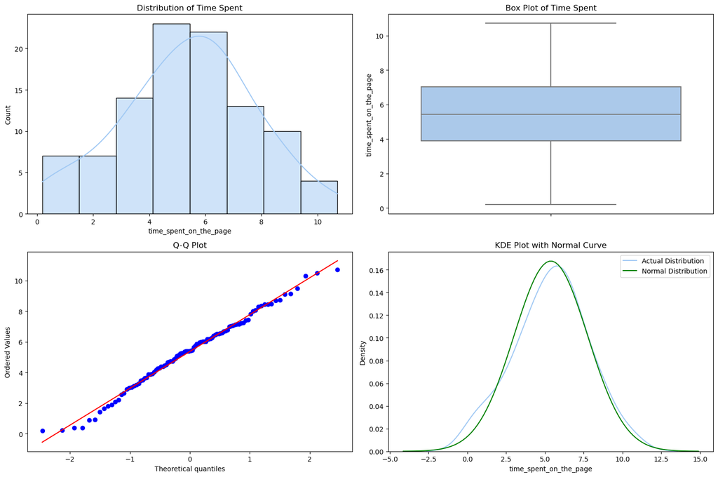

```python
# Set up the figure size
plt.figure(figsize=(15, 10))

plt.subplot(2, 2, 1)
sns.histplot(data=df, x='time_spent_on_the_page', kde=True)
plt.title('Distribution of Time Spent')

# 2. Box Plot
plt.subplot(2, 2, 2)
sns.boxplot(y=df['time_spent_on_the_page'])
plt.title('Box Plot of Time Spent')

# 3. Q-Q Plot
plt.subplot(2, 2, 3)
stats.probplot(df['time_spent_on_the_page'], dist="norm", plot=plt)
plt.title('Q-Q Plot')

# 4. KDE Plot with Normal curve
plt.subplot(2, 2, 4)
# Actual KDE
sns.kdeplot(data=df, x='time_spent_on_the_page', label='Actual Distribution')
# Generate points for ideal normal curve
x, y = generate_points_for_ideal_normal_curve(df['time_spent_on_the_page'])
# Plot ideal normal curve
plt.plot(x, y, 'g-', label='Normal Distribution')
plt.title('KDE Plot with Normal Curve')
plt.legend()

plt.tight_layout()
plt.show()
```

👀

- Time spent on the page follows an approximately normal pattern centered around 5 minutes
- The distribution is approximately normal, making it suitable for parametric hypothesis testing later.

```python
df['time_spent_on_the_page'].describe()
```

```
count    100.000000
mean       5.377800
std        2.378166
min        0.190000
25%        3.880000
50%        5.415000
75%        7.022500
max       10.710000
Name: time_spent_on_the_page, dtype: float64
```

🔍 **Observations**:

1. Users typically spend around 5.4 minutes on the page, showing decent engagement with the content.
2. Most visitors stay between 4-7 minutes, suggesting the content is neither too brief nor too lengthy for most users.
3. The time spent pattern is balanced and predictable, which makes it reliable for comparing old vs new page designs.
4. Some users leave very quickly (under 1 minute), indicating potential room for improving initial engagement.

👉 **Business lens**: The new design decisions should focus on maximizing this ~5-minute attention span, since that’s the typical engagement window.

### Helper Functions

```python
def analyze_categorical(df, column_name):
    """
    Helper function for categorical column analysis

    Parameters:
    df: DataFrame
    column_name: str - column to analyze
    """
    # 1. Frequency Analysis
    counts = df[column_name].value_counts()
    percentages = df[column_name].value_counts(normalize=True) * 100

    # 2. Create subplots for visualizations
    fig, (ax1, ax2) = plt.subplots(1, 2, figsize=(12, 5))

    # Bar plot
    sns.countplot(data=df, x=column_name, ax=ax1)
    ax1.set_title(f'Distribution of {column_name}')

    # Pie chart
    plt.pie(percentages, labels=counts.index, autopct='%1.1f%%')
    ax2.set_title(f'Percentage Distribution of {column_name}')

    # Print statistics
    print(f"\nDistribution for {column_name}:")
    for category, count in counts.items():
        print(f"{category}: {count} ({percentages[category]:.1f}%)")

    plt.tight_layout()
    plt.show()
```

### 2. `group`

```
Distribution for group:
control: 50 (50.0%)
treatment: 50 (50.0%)
```

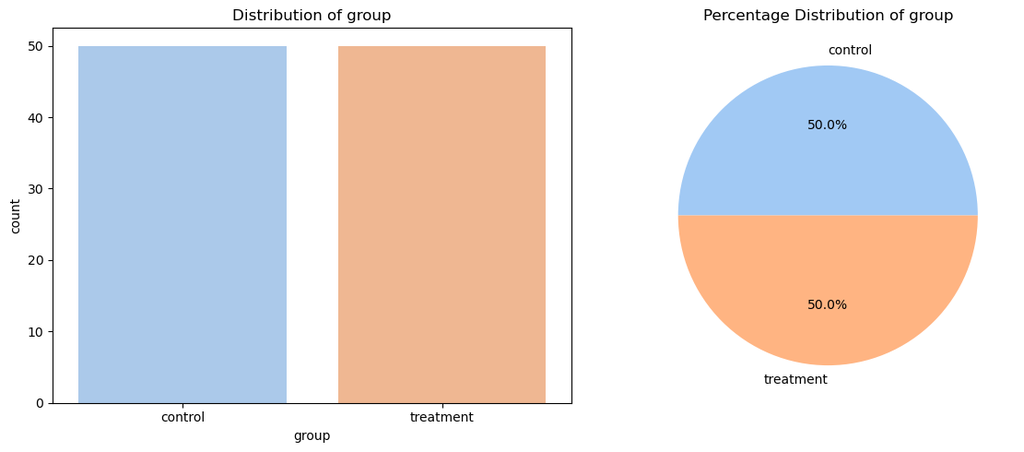

```python
analyze_categorical(df, 'group')
```

🔍 **Observations**

- The dataset is evenly split between the control group (50%) and treatment group (50%).
- This confirms that the experiment design is balanced with no sampling bias.

👉 Both landing pages were tested on an equal number of users, ensuring fair comparison for later statistical tests.

### 3. `landing_page`

```
Distribution for landing_page:
old: 50 (50.0%)
new: 50 (50.0%)
```

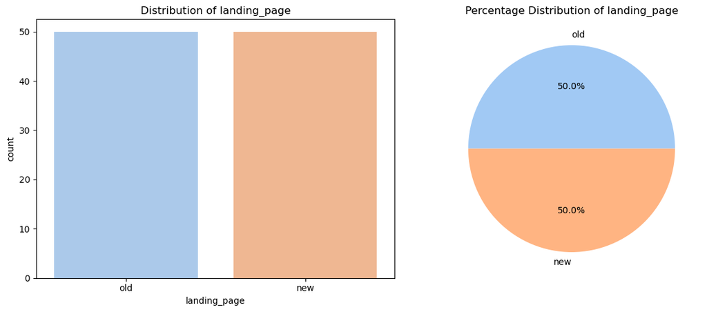

```python
analyze_categorical(df, 'landing_page')
```

🔍 **Observations**

- The experiment is properly structured with equal exposure (50 users each) to old and new page designs
- The balanced design helps minimize any bias in measuring page effectiveness
- Each version of the page has sufficient traffic for reliable performance comparison

### 4. `language_preferred`

```
Distribution for language_preferred:
Spanish: 34 (34.0%)
French: 34 (34.0%)
English: 32 (32.0%)
```

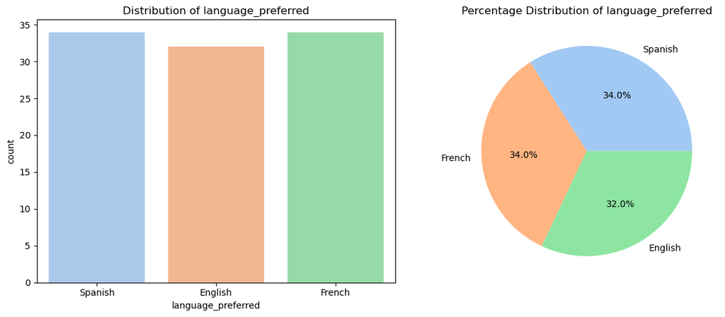

```python
analyze_categorical(df, 'language_preferred')
```

🔍 **Observations**

- Users are almost evenly distributed across **Spanish (34%)**, **French (34%)**, and **English (32%)**.
- The website attracts a diverse, international audience with balanced representation across English, Spanish, and French users
- Each language group has similar user numbers (32-34 users), indicating strong multi-language support
- No single language dominates the dataset.

👉 Business takeaway: Engagement and conversion analysis won’t be biased toward any one language group — all three are equally represented.

### 5. `converted`

```
Distribution for converted:
yes: 54 (54.0%)
no: 46 (46.0%)
```

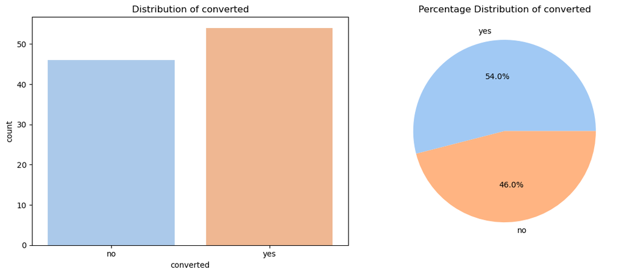

```python
analyze_categorical(df, 'converted')
```

🔍 **Observations**

- The website shows a strong overall conversion rate of 54%, with more than half of visitors becoming subscribers
- The conversion vs non-conversion split (54-46) suggests effective general engagement.
- The balanced distribution provides reliable data for comparing conversion performance between old and new pages

👉 Business takeaway: With conversion already near 50–50, improvements from the new landing page design could provide a meaningful edge in attracting more subscribers.

## Bivariate Analysis

### 1. `landing_page & time_spent_on_the_page`

```
Time Spent Summary by Landing Page:
              count    mean       std   min    25%    50%     75%    max
landing_page
new            50.0  6.2232  1.817031  1.65  5.175  6.105  7.1600  10.71
old            50.0  4.5324  2.581975  0.19  2.720  4.380  6.4425  10.30
```

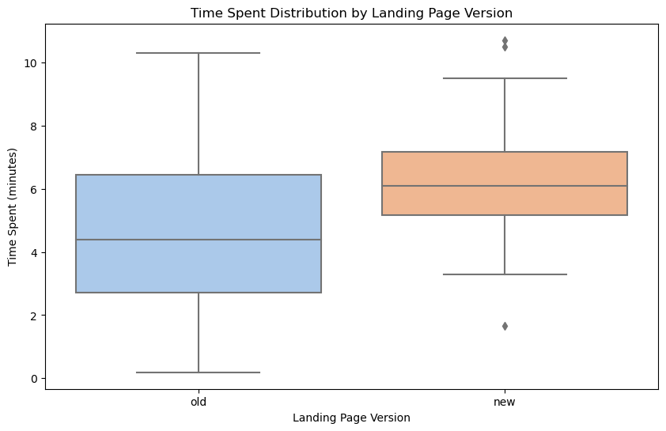

```python
# Boxplot to show distribution of time spent for each page version
sns.boxplot(x='landing_page', y='time_spent_on_the_page', data=df)
plt.title('Time Spent Distribution by Landing Page Version')
plt.xlabel('Landing Page Version')
plt.ylabel('Time Spent (minutes)')

# Add statistical summary
print("\nTime Spent Summary by Landing Page:")
print(df.groupby('landing_page')['time_spent_on_the_page'].describe())
```

🔍

1. The new page keeps users engaged longer, with average time spent increasing from 4.5 to 6.2 minutes
2. Users show more consistent engagement with the new design (less variation in time spent)
3. The new page seems better at preventing very short visits, with minimum time spent increasing from 0.2 to 1.7 minutes

👉 Business takeaway: The new landing page appears to increase engagement by ~1.7 minutes on average, a strong signal that the redesign is keeping users interested.

### 2 `landing_page & converted`

```
Conversion Rates by Landing Page (%):
converted       no   yes
landing_page
new           34.0  66.0
old           58.0  42.0
```

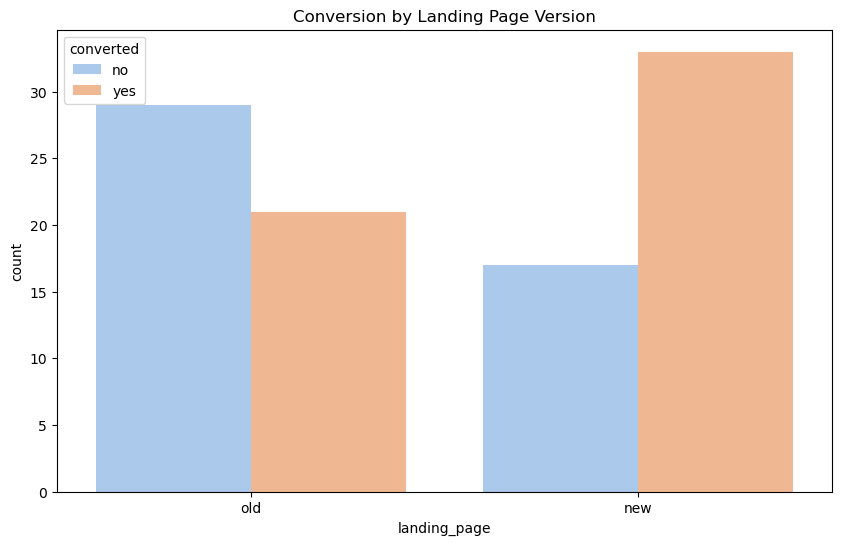

```python
# Create cross-tabulation
conversion_table = pd.crosstab(df['landing_page'], df['converted'], normalize='index') * 100
print("\nConversion Rates by Landing Page (%):")
print(conversion_table)

# Visualization
plt.title('Conversion by Landing Page Version')
plt.xlabel('Landing Page Version')
plt.ylabel('Number of Users')
sns.countplot(data=df, x='landing_page', hue='converted');
```

🔍

1. The new page design significantly improves conversion rate from 42% to 66%
2. For every 100 visitors, the new design converts 24 more users than the old design i.e **24% percentage point increase**
3. The redesign appears to be successful in achieving its primary goal of increasing subscriptions

👉 Business takeaway: The new landing page is not only keeping users longer but also driving significantly higher subscriptions - making it a strong candidate to replace the old design.

### 3. `language_preferred & converted`

```
Conversion Rates by Language Preference (%):
converted                  no        yes
language_preferred
English             34.375000  65.625000
French              55.882353  44.117647
Spanish             47.058824  52.941176
```

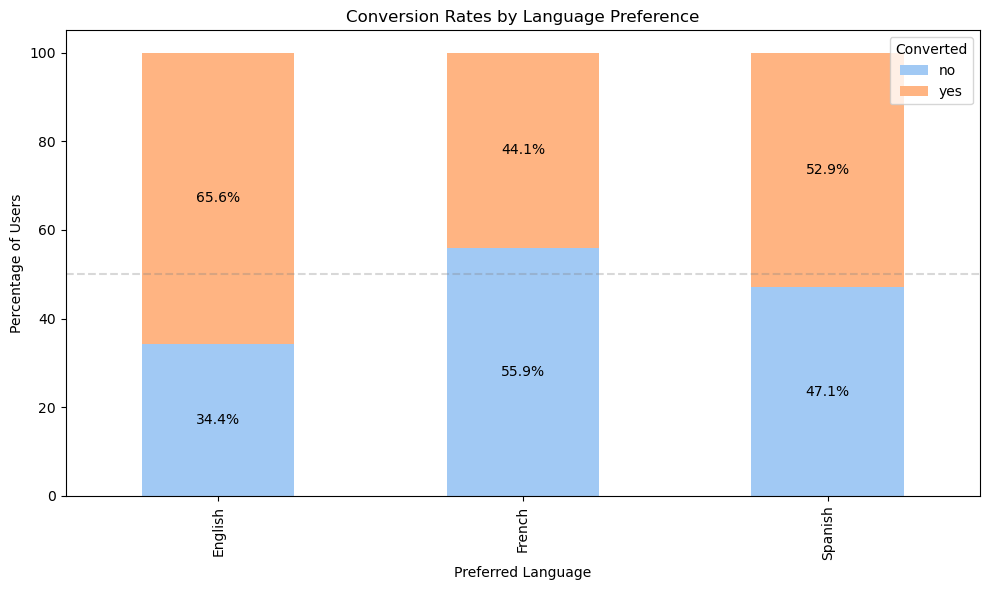

```python
# Create cross-tabulation with percentages
language_conversion = pd.crosstab(df['language_preferred'], df['converted'], normalize='index') * 100
print("\nConversion Rates by Language Preference (%):")
print(language_conversion)

# Create percentage-based stacked bar plot
conversion_percentages = pd.crosstab(df['language_preferred'], df['converted'], normalize='index') * 100

# Create percentage-based stacked bar plot
ax = conversion_percentages.plot(kind='bar', stacked=True)

# Add percentage labels inside bars
for c in ax.containers:
    # Add labels
    ax.bar_label(c, fmt='%.1f%%', label_type='center')

plt.title('Conversion Rates by Language Preference')
plt.xlabel('Preferred Language')
plt.ylabel('Percentage of Users')
plt.legend(title='Converted')
plt.axhline(y=50, color='gray', linestyle='--', alpha=0.3)  # Reference line at 50%

# Add percentage labels
plt.tight_layout();
```

🔍

👉 Business takeaway: Conversion performance varies noticeably by language. English users respond best to the landing page, while French users lag behind - suggesting possible benefits from localized content adjustments for different languages.

### 4. `language_preferred & time_spent_on_the_page`

```
Time Spent Summary by Language:
language_preferred    English     French    Spanish
count               32.000000  34.000000  34.000000
mean                 5.559062   5.253235   5.331765
std                  2.621079   2.675413   1.818095
min                  0.220000   0.400000   0.190000
25%                  3.617500   3.395000   4.475000
50%                  5.755000   5.315000   5.605000
75%                  7.137500   7.367500   6.515000
max                 10.500000  10.710000   8.720000
```

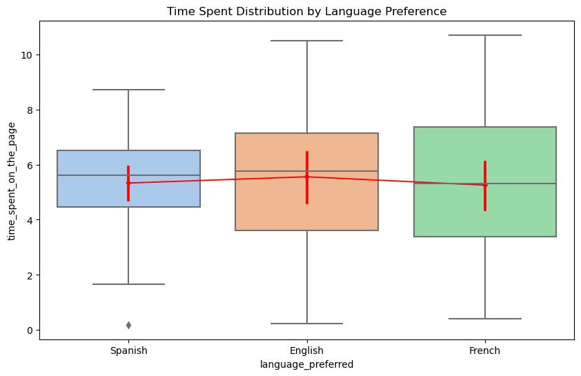

```python
# Statistical summary
print("\nTime Spent Summary by Language:")
print(df.groupby('language_preferred')['time_spent_on_the_page'].describe().T)

# Visualization
plt.figure(figsize=(10, 6))
sns.boxplot(x='language_preferred', y='time_spent_on_the_page', data=df)
plt.title('Time Spent Distribution by Language Preference')
plt.xlabel('Preferred Language')
plt.ylabel('Time Spent (minutes)')

# Add mean points
sns.pointplot(x='language_preferred', y='time_spent_on_the_page', data=df,
             color='red', markers='D', scale=0.5);
```

🔍

1. Users spend similar amounts of time (around 5.3-5.6 minutes) regardless of their language preference
2. Spanish-speaking users show more consistent engagement patterns with less variation in time spent
3. The similar engagement times suggest content is well-adapted across all three languages

👉 Business takeaway: This suggests that improving consistency for French users could help raise their conversion rates.

### 5. `time_spent_ont_the_page & convrted`

```
Time Spent Summary by Conversion Status:
           count      mean       std   min     25%    50%     75%    max
converted
no          46.0  3.915870  2.226897  0.19  2.3375  3.980  4.9225   9.15
yes         54.0  6.623148  1.708427  2.58  5.5000  6.495  7.3675  10.71
```

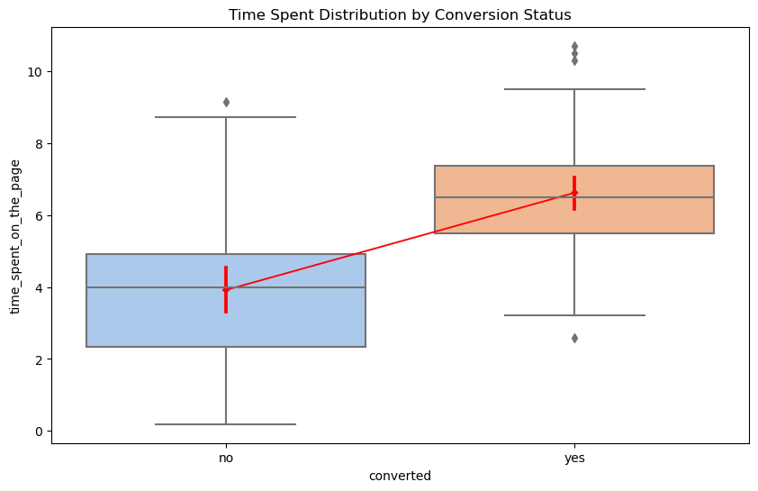

```python
# Statistical summary
print("\nTime Spent Summary by Conversion Status:")
print(df.groupby('converted')['time_spent_on_the_page'].describe())

# Box plot
sns.boxplot(x='converted', y='time_spent_on_the_page', data=df)
plt.title('Time Spent Distribution by Conversion Status')
plt.xlabel('Converted')
plt.ylabel('Time Spent (minutes)')

# Add mean points
sns.pointplot(x='converted', y='time_spent_on_the_page', data=df,
             color='red', markers='D', scale=0.5);
```

🔍

1. Users who convert spend significantly more time (6.6 vs 3.9 minutes) on the page
2. A minimum engagement of ~2.6 minutes appears necessary for conversion
3. Longer page visits strongly correlate with higher conversion likelihood, suggesting content successfully engages potential subscribers

👉 Business takeaway: More time on the page strongly correlates with higher conversion, suggesting that improving engagement factors (design, content, interactivity) could directly lift conversions.

### 6. `Time vs lang_pref vs converted`

> NOTE: this is multivariate !

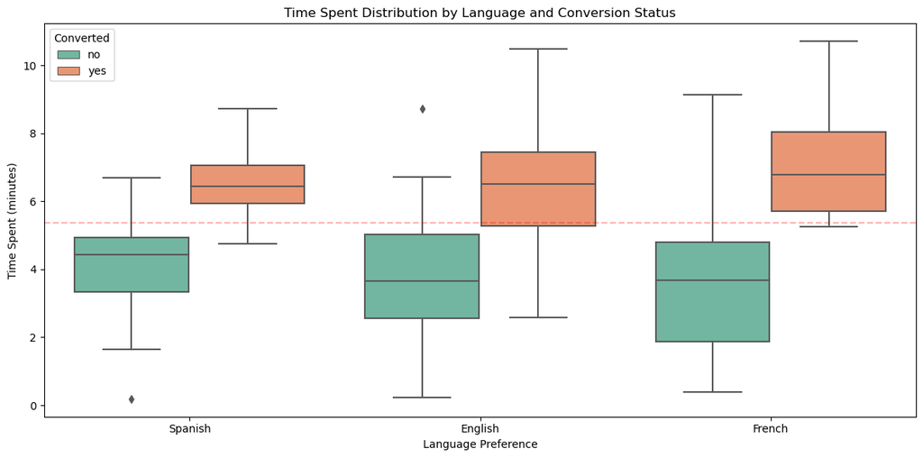

```python
# Create a faceted plot showing time spent distribution by both landing page and language
plt.figure(figsize=(12, 6))
sns.boxplot(x='language_preferred', y='time_spent_on_the_page',
            hue='converted', data=df,
            palette='Set2')

plt.title('Time Spent Distribution by Language and Conversion Status')
plt.xlabel('Language Preference')
plt.ylabel('Time Spent (minutes)')
plt.legend(title='Converted')

# Add reference line for overall mean
plt.axhline(y=df['time_spent_on_the_page'].mean(),
           color='red',
           linestyle='--',
           alpha=0.3,
           label='Overall Mean')

plt.tight_layout()
```

This plot will show:

- time spent patterns
- language preferences
- conversion status
- all in one comprehensive view

```python
# Get summary statistics grouped by both language and conversion
print("\nDetailed Summary by Language and Conversion Status:")
print(df.groupby(['language_preferred', 'converted'])['time_spent_on_the_page'].describe().T)

# Get conversion rates by language for each time spent quartile
df['time_quartile'] = pd.qcut(df['time_spent_on_the_page'], q=4, labels=['Q1', 'Q2', 'Q3', 'Q4'])
conversion_by_lang_time = pd.crosstab([df['language_preferred'], df['time_quartile']],
                                     df['converted'],
                                     normalize='index') * 100

print("\nConversion Rates by Language and Time Spent Quartile (%):")
conversion_by_lang_time
```

```
Detailed Summary by Language and Conversion Status:
language_preferred    English                French              Spanish  \
converted                  no        yes         no       yes         no
count               11.000000  21.000000  19.000000  15.00000  16.000000
mean                 3.810909   6.474762   3.861579   7.01600   4.052500
std                  2.548001   2.200267   2.535368   1.62778   1.674385
min                  0.220000   2.580000   0.400000   5.25000   0.190000
25%                  2.565000   5.280000   1.865000   5.71500   3.335000
50%                  3.650000   6.520000   3.680000   6.79000   4.430000
75%                  5.020000   7.460000   4.810000   8.05500   4.940000
max                  8.730000  10.500000   9.150000  10.71000   6.700000

language_preferred
converted                 yes
count               18.000000
mean                 6.468889
std                  1.016562
min                  4.750000
25%                  5.945000
50%                  6.440000
75%                  7.060000
max                  8.720000

Conversion Rates by Language and Time Spent Quartile (%):
```

| language_preferred | converted time_quartile | no | yes |
| --- | --- | --- | --- |
| English | Q1 | 60.000000 | 40.000000 |
|  | Q2 | 40.000000 | 60.000000 |
|  | Q3 | 25.000000 | 75.000000 |
|  | Q4 | 11.111111 | 88.888889 |
| French | Q1 | 100.000000 | 0.000000 |
|  | Q2 | 66.666667 | 33.333333 |
|  | Q3 | 0.000000 | 100.000000 |
|  | Q4 | 30.000000 | 70.000000 |
| Spanish | Q1 | 100.000000 | 0.000000 |
|  | Q2 | 70.000000 | 30.000000 |
|  | Q3 | 25.000000 | 75.000000 |
|  | Q4 | 0.000000 | 100.000000 |

🔍

1. Longer engagement consistently leads to better conversion across all languages, with 70-100% conversion rates in the highest time quartile
2. English content shows most consistent progression in conversion rates, suggesting well-optimized content flow
3. French and Spanish users need more initial engagement, as very short visits (Q1) show no conversions

These insights suggest focusing on:

- Improving initial engagement for non-English content
- Maintaining the effective English content structure
- Strategies to keep users engaged beyond the first quartile of time

## Key Insights from EDA

**Key Insights from EDA:**

1. Individual Variables:
   - Time spent averages 5.4 minutes, with consistent engagement between 4-7 minutes
   - Perfect 50-50 split between old/new page designs
   - Overall 54% conversion rate across all users
   - Balanced language distribution (32-34% each for English, French, Spanish)
2. Key Relationships:
   - New page significantly improves both engagement (6.2 vs 4.5 minutes) and conversion (66% vs 42%)
   - English users show highest conversion (66%) compared to French (44%) and Spanish (53%)
   - Users who convert spend notably more time (6.6 vs 3.9 minutes)
   - Time spent strongly predicts conversion across all languages (70-100% conversion in highest quartile)
3. Critical Findings:
   - Minimum 2.6 minutes engagement needed for conversion
   - New design prevents very short visits (minimum 1.7 vs 0.2 minutes)
   - Non-English content needs improvement in initial engagement

**Summary**

# REMEMBER

### Test Statistics Decision Helper (Normal | Continuous)

1. **Quick Visual Check First:**
   - Start with the visualization (QQ plots, histograms) to get a rough idea
   - If data looks extremely non-normal (heavy skew, lots of outliers), go straight to Mann-Whitney U
2. **Sample Size Consideration:**
   - If your sample size is large (>30 per group), you can be more relaxed about normality
   - The t-test will still be valid due to the Central Limit Theorem
3. **Formal Testing:**
   - Shapiro-Wilk and Levene's tests are very sensitive with large samples
   - They might reject normality even for minor deviations that don't practically matter
   - Consider them guidelines rather than strict gates

### QQ Plot Interpretation

✅ Interpretation of Q-Q plots:

- If the points roughly follow the diagonal line → data is approximately normal
- Deviations at ends → heavy tails/skewness

### Normality & Variance Test Interpretation

**Shapiro-Wilk Test** (tests for normality)

- H₀: Data is normally distributed
- H₁: Data is not normally distributed
- Decision rule: If p-value > 0.05, data is considered normal
- Interpret separately for each group

**Levene's Test** (tests for equality of variances)

- H₀: Variances are equal
- H₁: Variances are not equal
- Decision rule: If p-value > 0.05, variances are considered equal

In the context of a **Shapiro-Wilk normality check** (or any statistical test comparing groups):

- **Control group** → the baseline or “old/standard” group (e.g., old landing page).
- **Treatment group** → the group that received the new intervention (e.g., new landing page).

You usually run Shapiro **separately for each group** to see if the **data in that group is roughly normal** before deciding on t-test vs non-parametric test.

# Helper Functions

```python
from scipy.stats import t
def plot_t_distribution(t_stat, dof, alpha=0.05, alternative='two-sided'):
    """
    Visualize t-distribution with test statistic and rejection region

    Parameters:
    -----------
    t_stat : float
        Calculated t-statistic value
    df : int
        Degrees of freedom
    alpha : float, optional
        Significance level (default 0.05)
    alternative : str, optional
        'two-sided', 'greater' (right-tailed), or 'less' (left-tailed)
    """
    x = np.linspace(-4, 4, 1000)
    t_dist = t.pdf(x, dof)

    plt.figure(figsize=(10, 6))
    plt.plot(x, t_dist, 'b-', label='t-distribution')

    # Handle different types of tests
    if alternative == 'two-sided':
        crit_left = t.ppf(alpha/2, dof)
        crit_right = t.ppf(1-alpha/2, dof)

        plt.fill_between(x[x <= crit_left], t_dist[x <= crit_left],
                        color='red', alpha=0.5)
        plt.fill_between(x[x >= crit_right], t_dist[x >= crit_right],
                        color='red', alpha=0.5, label='Rejection region')

        plt.axvline(x=crit_left, color='g', linestyle='--',
                   label=f'Critical values (α={alpha})')
        plt.axvline(x=crit_right, color='g', linestyle='--')

        # Add annotations for critical values
        plt.text(crit_left, 0.05, f'{crit_left:.3f}', rotation=90, color='g')
        plt.text(crit_right, 0.05, f'{crit_right:.3f}', rotation=90, color='g')

    elif alternative == 'greater':
        crit_right = t.ppf(1-alpha, dof)
        plt.fill_between(x[x >= crit_right], t_dist[x >= crit_right],
                        color='red', alpha=0.5, label='Rejection region')
        plt.axvline(x=crit_right, color='g', linestyle='--',
                   label=f'Critical value (α={alpha})')
        # Add annotation for critical value
        plt.text(crit_right, 0.05, f'{crit_right:.3f}', rotation=90, color='g')

    elif alternative == 'less':
        crit_left = t.ppf(alpha, dof)
        plt.fill_between(x[x <= crit_left], t_dist[x <= crit_left],
                        color='red', alpha=0.5, label='Rejection region')
        plt.axvline(x=crit_left, color='g', linestyle='--',
                   label=f'Critical value (α={alpha})')
        # Add annotation for critical value
        plt.text(crit_left, 0.05, f'{crit_left:.3f}', rotation=90, color='g')

    # Add t-statistic line and annotation
    plt.axvline(x=t_stat, color='r', linestyle='--',
                label=f't-statistic = {t_stat:.3f}')
    plt.text(t_stat, 0.05, f'{t_stat:.3f}', rotation=90, color='r')

    plt.title('T-Distribution with Test Statistic')
    plt.xlabel('t-value')
    plt.ylabel('Density')
    plt.legend()
    plt.grid(True, alpha=0.3)
```

```python
df = df_original.copy()
```

# Q1 : Do the users spend more time on the new landing page than the old landing page?

#### **Visual Analysis**

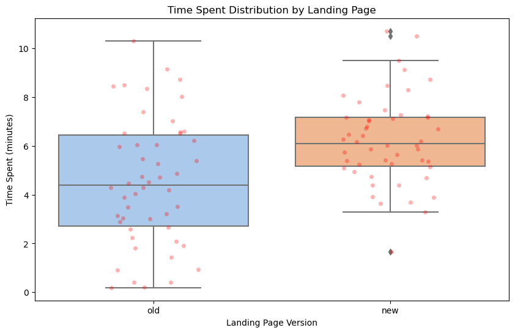

```python
# Box plot with individual points
sns.boxplot(x='landing_page', y='time_spent_on_the_page', data=df)
sns.stripplot(x='landing_page', y='time_spent_on_the_page', data=df,
              color='red', alpha=0.3, jitter=0.2)

plt.title('Time Spent Distribution by Landing Page')
plt.xlabel('Landing Page Version')
plt.ylabel('Time Spent (minutes)')
```

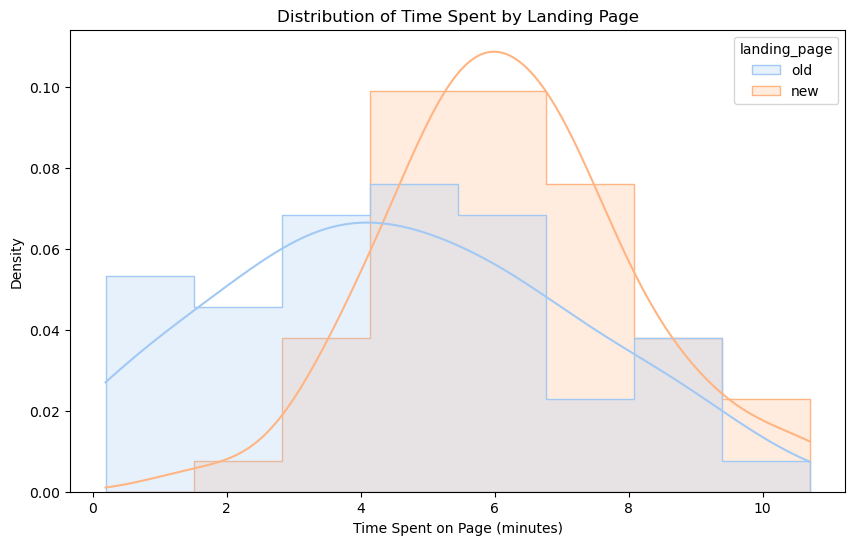

```python
sns.histplot(data=df, x='time_spent_on_the_page', hue='landing_page', kde=True, element="step", stat="density")
plt.title("Distribution of Time Spent by Landing Page")
plt.xlabel("Time Spent on Page (minutes)")
plt.ylabel("Density")
plt.show()
```

#### **Step 1: Identify Variable Types ✅**

We need to select appropriate test based on:

1. **Nature of Variables**:
   - Independent Variable (Landing page): **Categorical** with 2 groups (old/new)
   - Dependent Variable (Time spent): **Continuous**
   - Groups are: Independent samples
2. **Possible Tests Based on Variable Types**:
   - Independent t-test (parametric)
   - Mann-Whitney U test (non-parametric)
3. **Decision Will Depend On**:
   - Normality of data
   - Equality of variances
   - Sample size (we have 50 in each group) (ie 50 > 30 : CLT)

#### **Step 2: Hypothesis Formulation ✅**

Let μ₁ = mean time spent on new page

Let μ₂ = mean time spent on old page

**Null Hypothesis (H₀)**:

- μ₁ ≤ μ₂
- "Users do not spend more time on the new landing page than the old page"
- or
- The mean time spent on the new landing page is equal to the mean time spent on the old landing page.

**Alternative Hypothesis (H₁)**:

- μ₁ > μ₂
- "Users spend more time on the new landing page than the old page"

**Test Characteristics**:

- One-tailed test (specifically interested if new page increases time)
- Significance level (α) = 0.05

> Note: This is a one-tailed test because the question specifically asks if time spent is more.

#### **Step 3: Test Statistic Decision ✅**:

**Guidelines**

1. **Sample Size Check**:
   - We have 50 samples in each group (>30)
   - Due to Central Limit Theorem, we can be somewhat relaxed about normality
2. **Visual Check** (from our earlier visualization):
   - Both groups showed relatively symmetric distributions
   - No extreme outliers or heavy skew
   - Boxplots suggested different spreads between groups
3. **Formal Testing**:
   - Shapiro-Wilk test for normality (for each group)
   - Levene's test for equality of variances

🧠 **REMEMBER**:

**For T-test Validity:**

- The independent t-test assumes both normality and equal variances
- When these assumptions are violated, the test can give unreliable results

**Visualization check for Normality**

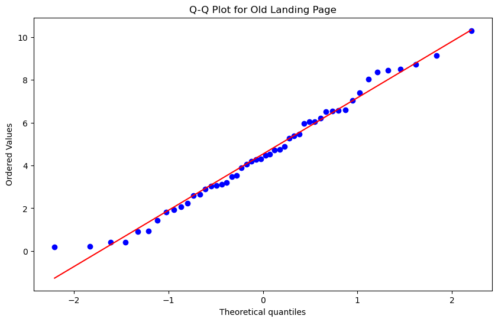

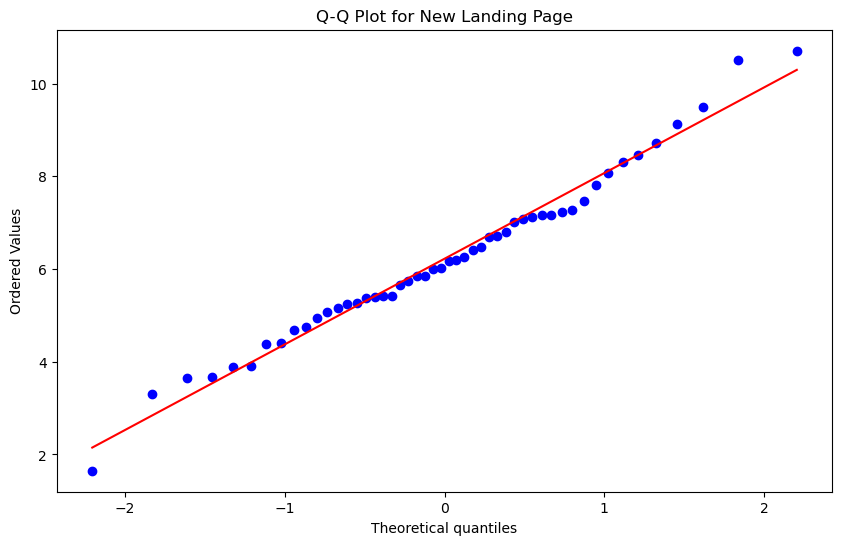

```python
# Q-Q plots
groups = df['landing_page'].unique()
for g in groups:
    stats.probplot(df[df['landing_page']==g]['time_spent_on_the_page'], dist="norm", plot=plt)
    plt.title(f"Q-Q Plot for {g.capitalize()} Landing Page")
    plt.show()
```

✅ Interpretation of Q-Q plots:

- If the points roughly follow the diagonal line → data is approximately normal
- Deviations at ends → heavy tails/skewness

From above plots, most points do lie on line

**Formal Stats Testing**

```python
# Test for Normality (Shapiro-Wilk)
new_page = df[df['landing_page'] == 'new']['time_spent_on_the_page']
old_page = df[df['landing_page'] == 'old']['time_spent_on_the_page']
```

```python
len(new_page), len(old_page)
```

```
(50, 50)
```

**Tests for Normality**

```python
# Shapiro-Wilk test for both groups
print("Normality Test (Shapiro-Wilk):")
_, p_new = stats.shapiro(new_page)
_, p_old = stats.shapiro(old_page)
print(f"[Treatment] New page: p-value = {p_new:.4f}")
print(f"[Control] Old page: p-value = {p_old:.4f}")
```

```
Normality Test (Shapiro-Wilk):
[Treatment] New page: p-value = 0.8040
[Control] Old page: p-value = 0.4561
```

👀

Both p-values > 0.05, So time spent on both pages is approximately normally distributed.

**Test for Variances**

```python
# Test for Equal Variances (Levene's test)
_, p_levene = stats.levene(new_page, old_page)

print(f"Levene's test: p-value = {p_levene:.4f}")
```

```
Levene's test: p-value = 0.0090
```

👀

p-value = 0.0090 < 0.05, indicating unequal variances between groups

> NOTE: here 0.05 used in shapiro and levene has nothing to do with level of significance (alpha) we decide for our hypothesis test. both are independent It's that 0.05 is generally used for test of normality and variances

💡

We **can still use a t-test** if data is normal, but we should use **Welch’s t-test** (t-test with `equal_var=False`) to account for unequal variances.

- Standard t-test → assumes equal variances
- Welch’s t-test → relaxes variance equality assumption

Normality is more important than variance equality for choosing a t-test variant.

✅

**Final Test Selection Decision:**

- Groups are normally distributed (Shapiro-Wilk ✓)
- But have unequal variances (Levene's ✗)
- Therefore, we will use **Welch's t-test** (unequal variance t-test)

This is appropriate because:

- Handles unequal variances
- Still powerful for normal data
- One-tailed test (as per our hypothesis)

#### **Step 4: Execute Test ✅**

**Significance Level:**

- α = 0.05 (5% significance level, as specified in problem statement)

**Decision Rule:**

- If p-value < 0.05: Reject H₀ (evidence supports new page increases time)
- If p-value ≥ 0.05: Fail to reject H₀ (insufficient evidence)

```python
# Define significance level
alpha = 0.05
```

```python
is_equal_var = False # p_var < 0.05, so we use Welch's t-test
```

```python
# Welch's t-test (one-tailed)
t_stat, p_value = stats.ttest_ind(
    new_page, # treatment
    old_page, # control (ie baseline)
    equal_var=is_equal_var,  # Welch's t-test
    alternative="greater",
)  # one-tailed
print(f"t-stat: {t_stat}")
print(f"p-value: {p_value}")
```

```
t-stat: 3.7867702694199856
p-value: 0.00013923812251665497
```

🧐 that’s a **very small p-value**

- p-value ≈ 0.00014 < 0.05 → reject H₀

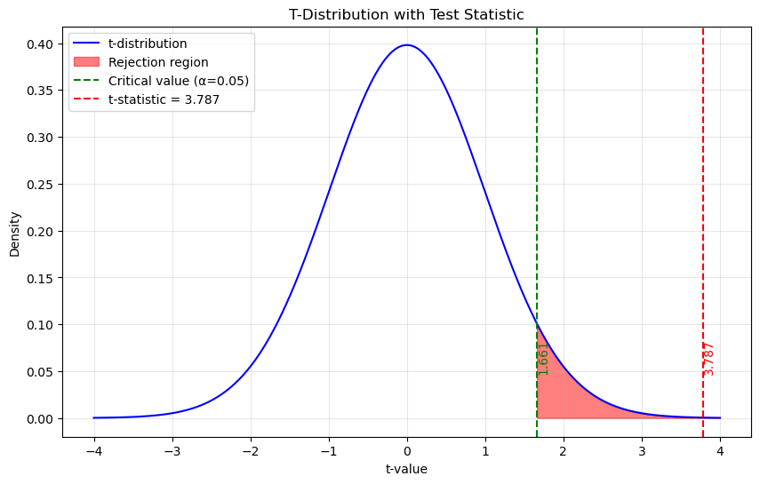

```python
# pproximate df for Welch's t-test = n1 + n2 - 2
degrees_of_freedom = len(new_page) + len(old_page) - 2
plot_t_distribution(t_stat, dof=degrees_of_freedom, alpha=alpha, alternative="greater")
```

#### **Interpretation ✅**

**T-test (Welch, one-tailed) Result:**

- p-value ≈ 0.00014 < 0.05 → **reject H₀**

**Inference:**

- There is **strong statistical evidence** that users spend **more time on the new landing page** than on the old page.
- Mean difference (from earlier EDA) ≈ **1.69 minutes** (6.22 – 4.53), which is practically meaningful.

**Business takeaway:** 🤔

- Users spend significantly more time on the new page design
- The new design is **effectively keeping users engaged longer**, which is a positive signal for increasing conversions.

# Q2: Is the conversion rate (the proportion of users who visit the landing page and get converted) for the new page greater than the conversion rate for the old page?

#### **Visualization**

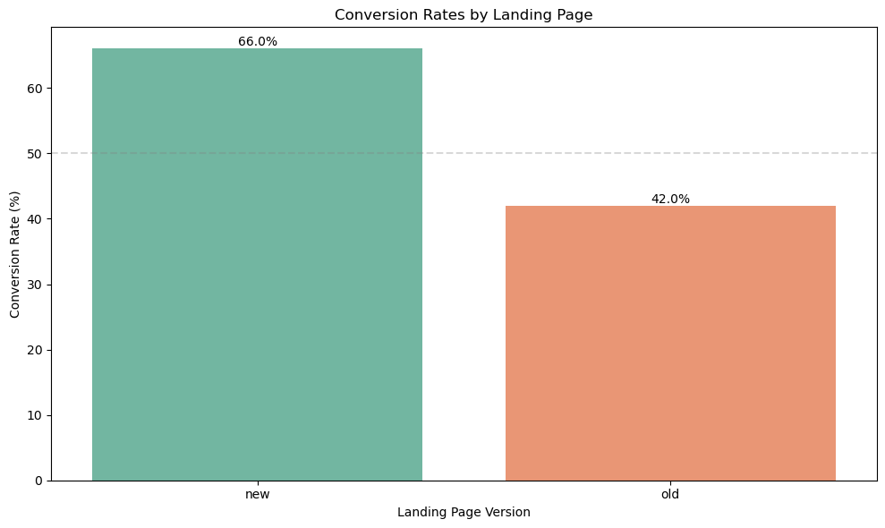

```python
# Calculate conversion rates from data
conversion_rates = pd.crosstab(df['landing_page'], df['converted'], normalize='index') * 100

# Create bar plot using seaborn
sns.barplot(x=conversion_rates.index, y=conversion_rates['yes'],
            palette='Set2')

# Customize plot
plt.title('Conversion Rates by Landing Page')
plt.xlabel('Landing Page Version')
plt.ylabel('Conversion Rate (%)')

# Add percentage labels on bars
for i in plt.gca().containers:
    plt.gca().bar_label(i, fmt='%.1f%%')

# Add reference line at 50%
plt.axhline(y=50, color='gray', linestyle='--', alpha=0.3)

plt.tight_layout()
```

```python
print('Conversion Rates (%) by Landing Page:')
conversion_rates
```

```
Conversion Rates (%) by Landing Page:
```

| converted landing_page | no | yes |
| --- | --- | --- |
| new | 34.0 | 66.0 |
| old | 58.0 | 42.0 |

```python
# sample size check
df['landing_page'].value_counts()
```

```
landing_page
old    50
new    50
Name: count, dtype: int64
```

#### **Step 1: Identify Variable Types ✅**

**1. Nature of Variables**:

- Independent Variable (`Landing Page`): Categorical (2 groups)
- Dependent Variable (`Conversion`): Categorical (binary: yes/no)
- Relationship: Comparing proportions between independent groups

**2. Possible Tests Based on Variable Types**: Since both variables are categorical and we want to compare proportions, the usual approach is:

- Two-proportion z-test
- Chi-square test of independence
- Fisher's exact test

Because the question asks “**is the conversion rate for the new page greater**”, a **one-tailed test** is appropriate.

**3. Decision Depends On**:

- Sample size requirements (n×p ≥ 10 and n×(1-p) ≥ 10)
- Independence of observations
- Random sampling

**Final Test Selection**: Two-proportion z-test (Because we have adequate sample sizes and specifically want to test if one proportion is greater than the other)

#### **Step 2: Formulate Hypotheses ✅**

**Hypothesis Formulation**

Let p₁ = conversion rate for new page Let p₂ = conversion rate for old page

**Null Hypothesis (H₀)**:

- p₁ ≤ p₂
- (conversion rate is the same)
- "The new page's conversion rate is not greater than the old page's conversion rate"

**Alternative Hypothesis (H₁)**:

- p₁ > p₂
- "The new page's conversion rate is greater than the old page's conversion rate"

**Test Characteristics**:

- One-tailed test (specifically interested if new page increases conversion)
- Significance level (α) = 0.05

#### **Step 3: Test Statistic Decision ✅**

For Two-proportion z-test, we need to verify sample size requirements:

**Sample Size Requirements Check**:

1. For New Page (n₁ = 50, p₁ = 0.66):
   - n₁p₁ = 50 × 0.66 = 33 ≥ 10 ✓
   - n₁(1-p₁) = 50 × 0.34 = 17 ≥ 10 ✓
2. For Old Page (n₂ = 50, p₂ = 0.42):
   - n₂p₂ = 50 × 0.42 = 21 ≥ 10 ✓
   - n₂(1-p₂) = 50 × 0.58 = 29 ≥ 10 ✓

**Decision**:

- All requirements met (all values ≥ 10)
- Can proceed with two-proportion z-test
- Will use one-tailed test (testing for improvement)

#### **Step 4: Execute test** ✅

```python
# Define significance level
alpha = 0.05
```

```python
df['converted_num'] = df['converted'].map({'yes': 1, 'no': 0})
```

```python
conversions = df.groupby('landing_page')['converted_num'].agg(['sum', 'count'])
conversions['rate'] = conversions['sum'] / conversions['count']
print("Conversion summary by landing page:\n", conversions)
```

```
Conversion summary by landing page:
               sum  count  rate
landing_page
new            33     50  0.66
old            21     50  0.42
```

```python
counts_table = pd.crosstab(df['landing_page'], df['converted'])
counts_table
```

| converted landing_page | no | yes |
| --- | --- | --- |
| new | 17 | 33 |
| old | 29 | 21 |

```python
# Prepare data for z-test
count = [counts_table.loc["new", "yes"], counts_table.loc["old", "yes"]]  # successes
nobs = [
    counts_table.loc["new"].sum(),
    counts_table.loc["old"].sum(),
]  # total observations

# Define significance level
alpha = 0.05

# Conduct one-tailed test
stat, p_value = proportions_ztest(count=count, nobs=nobs, alternative="larger")
```

```python
print(f"Z-statistic: {stat:.4f}, p-value: {p_value:.4f}")
```

```
Z-statistic: 2.4077, p-value: 0.0080
```

#### Interpretation ✅

**Statistical Interpretation:**

- Z-statistic = 2.4077
- p-value = 0.0080 < α (0.05)
- Decision: Reject the null hypothesis

**Inference**:

- p-value < 0.05 → reject H₀
- There is strong evidence that the conversion rate for the new page is greater than the old page.

**Business Interpretation**:

1. The new page significantly improves conversion rate (66% vs 42%)
2. The improvement of 24 percentage points is statistically significant
3. The redesign successfully achieves its goal of increasing user conversion

💡 **Business takeaway:**

- The new landing page not only keeps users engaged longer but also **significantly increases subscription rates** (66% vs 42%).
- This supports rolling out the new design as a permanent improvement.

# Q3: Does the converted status depend on the preferred language?

#### **Visualization**

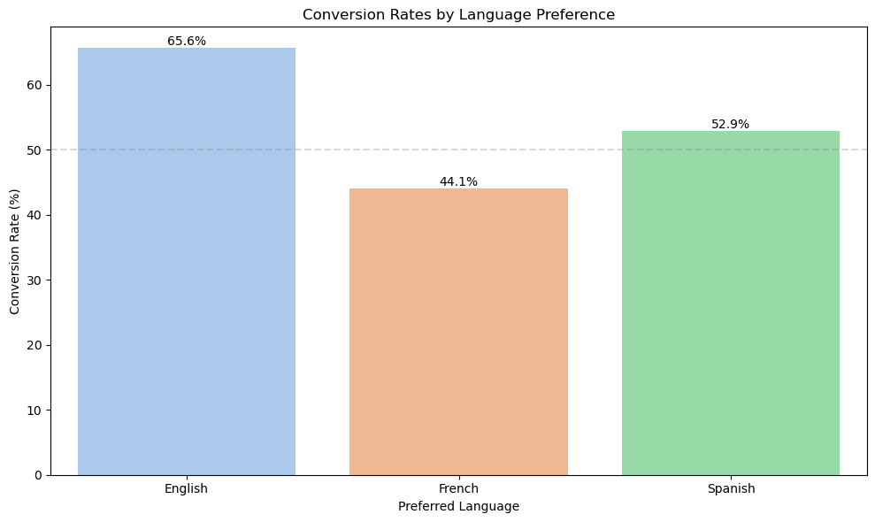

```python
# Calculate conversion rates by language
lang_conversion = pd.crosstab(df['language_preferred'],
                            df['converted'],
                            normalize='index') * 100


# Create stacked bar plot
sns.barplot(x=lang_conversion.index,
            y=lang_conversion['yes'])

# Customize plot
plt.title('Conversion Rates by Language Preference')
plt.xlabel('Preferred Language')
plt.ylabel('Conversion Rate (%)')

# Add percentage labels
for i in plt.gca().containers:
    plt.gca().bar_label(i, fmt='%.1f%%')

# Add reference line at 50%
plt.axhline(y=50, color='gray', linestyle='--', alpha=0.3)

plt.tight_layout()
```

#### **Step 1: Identify Variable type ✅**

**Variable Types Analysis**:

- Variable 1: Language preferred (**Categorical**, 3 levels: English, French, Spanish)
- Variable 2: Conversion status (**Categorical**, 2 levels: yes/no)
- Testing: Association/dependency between two categorical variables

> Since both are categorical, the **Chi-square test of independence** is the standard choice.

**Possible Tests Based on Variable Types**:

- Chi-square test of independence
- Fisher's exact test

**Final Test Selection**: Chi-square test of independence (Because we have adequate sample size and testing dependency between categorical variables)

#### **Step 2: Formulate hypotheses ✅**

**Null Hypothesis (H₀)**:

- "There is no association/dependency between language preference and conversion status"
- "Conversion status is independent of preferred language"
- Mathematically: P(conversion|language) = P(conversion)

**Alternative Hypothesis (H₁)**:

- "There is an association/dependency between language preference and conversion status"
- "Conversion status depends on preferred language"
- Mathematically: P(conversion|language) ≠ P(conversion)

**Test Characteristics**:

- Two-tailed test (testing for any association, not direction)
- Significance level (α) = 0.05

#### **Step 3: Test Statistic Decision: ✅**

```python
# Observed frequencies
contingency_table = pd.crosstab(df['language_preferred'], df['converted'])

# Expected frequencies
_, _, _, expected = chi2_contingency(contingency_table)
expected
```

```
array([[14.72, 17.28],
       [15.64, 18.36],
       [15.64, 18.36]])
```

**Decision**

- All chi-square test assumptions are met:
  1. Random sampling ✓
  2. Independence ✓
  3. Expected frequencies ≥ 5 ✓
- Can proceed with chi-square test of independence

#### **Step 4 Execute test** ✅

```python
# Define significance level
alpha = 0.05

# Create contingency table
contingency_table = pd.crosstab(df['language_preferred'], df['converted'])

# Perform chi-square test
chi2_stat, p_value, dof, expected = chi2_contingency(contingency_table)

# Print results
print(f"Chi-square statistic: {chi2_stat:.4f}")
print(f"p-value: {p_value:.4f}")
print(f"Degrees of freedom: {dof}")
```

```
Chi-square statistic: 3.0930
p-value: 0.2130
Degrees of freedom: 2
```

#### **Interpretation** ✅

**Chi-Square Test Result**:

- Chi-square statistic ≈ 3.09
- p-value ≈ 0.213 > 0.05
- Degrees of freedom = 2

**Inference**

- p-value > 0.05 → fail to reject H₀
- There is no significant evidence that conversion depends on preferred language.

**Business Interpretation** :

1. Language preference does not significantly influence conversion rates
2. The website appears to be equally effective across all language versions
3. No need for language-specific optimization of conversion strategies

💡 **Business takeaway:**

- Conversion rates appear **relatively independent of language**.
- Efforts to increase subscriptions may be better focused on **landing page design and engagement**, rather than language-specific interventions.

# Q4: Is the mean time spent on the new page same for the different language users?

#### **Visualization**

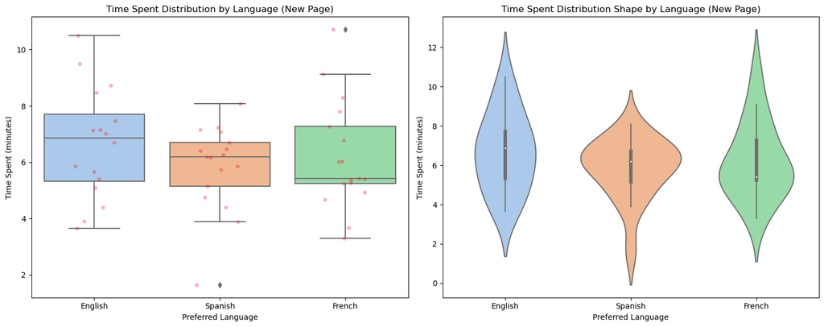

```python
# Create figure with two subplots
fig, (ax1, ax2) = plt.subplots(1, 2, figsize=(15, 6))

# 1. Box plot with individual points
sns.boxplot(x='language_preferred', y='time_spent_on_the_page',
            data=df[df['landing_page']=='new'], ax=ax1)
sns.stripplot(x='language_preferred', y='time_spent_on_the_page',
              data=df[df['landing_page']=='new'],
              color='red', alpha=0.3, jitter=0.2, ax=ax1)
ax1.set_title('Time Spent Distribution by Language (New Page)')
ax1.set_xlabel('Preferred Language')
ax1.set_ylabel('Time Spent (minutes)')

# 2. Violin plot (shows distribution shape)
sns.violinplot(x='language_preferred', y='time_spent_on_the_page',
               data=df[df['landing_page']=='new'], ax=ax2)
ax2.set_title('Time Spent Distribution Shape by Language (New Page)')
ax2.set_xlabel('Preferred Language')
ax2.set_ylabel('Time Spent (minutes)')

plt.tight_layout()
```

#### **Step 1: Identify Variable Types** ✅

**Variable Types Analysis**:

- Independent Variable: Language preferred (**Categorical**, 3 levels: English, French, Spanish)
- Dependent Variable: Time spent (**Continuous**)
- We are only interested in the new page, so we’ll filter landing_page == 'new'.
- Testing: Comparing means across 3 independent groups

Since we are comparing means across >2 independent groups, the standard approach is:

1. **Possible Tests Based on Variable Types**:
- One-way ANOVA (parametric) (if normality + equal variances)
- Kruskal-Wallis test (non-parametric) (if normality assumption is violated)

**Final Test Selection**: Will be determined after checking assumptions

- If assumptions met → One-way ANOVA
- If assumptions violated → Kruskal-Wallis

#### **Step 2: Formulate hypotheses** ✅

- Let μ₁ = mean time spent on new page by English users
- Let μ₂ = mean time spent on new page by French users
- Let μ₃ = mean time spent on new page by Spanish users

**Null Hypothesis (H₀)**:

- μ₁ = μ₂ = μ₃
- "For the new page, mean time spent is same across all language preferences"

**Alternative Hypothesis (H₁)**:

- At least one mean is different
- "For the new page, mean time spent differs for at least one language group"

#### **Step 3: Test Statistic Decision** ✅

```python
# Filter for new page only
new_page_df = df[df['landing_page'] == 'new']
```

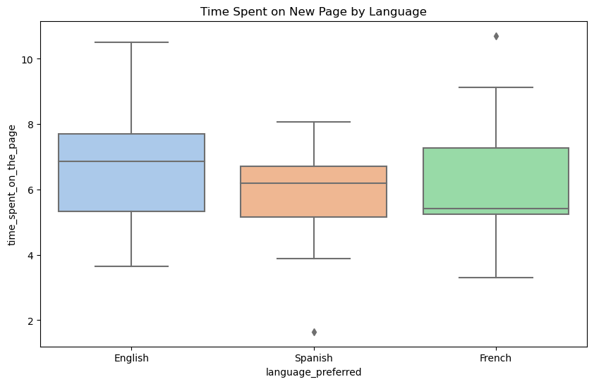

```python
# Boxplot
sns.boxplot(data=new_page_df, x='language_preferred', y='time_spent_on_the_page')
plt.title("Time Spent on New Page by Language")
plt.show()
```

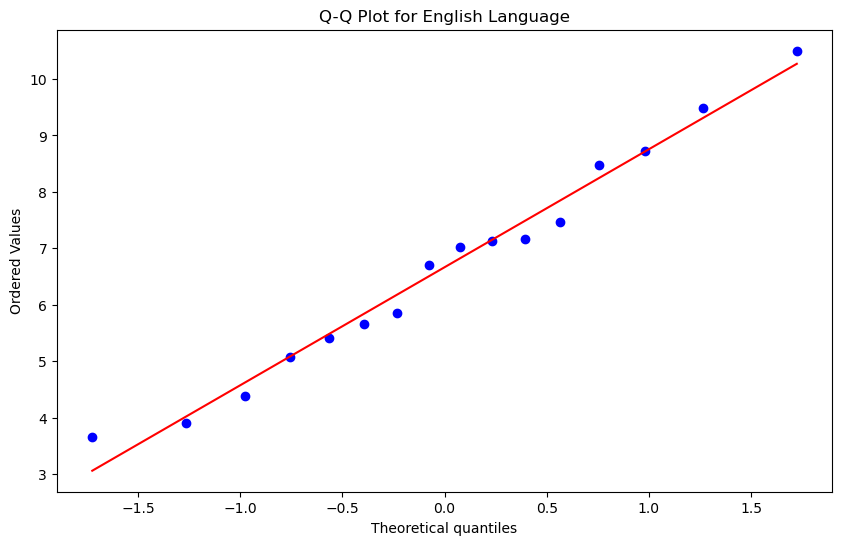

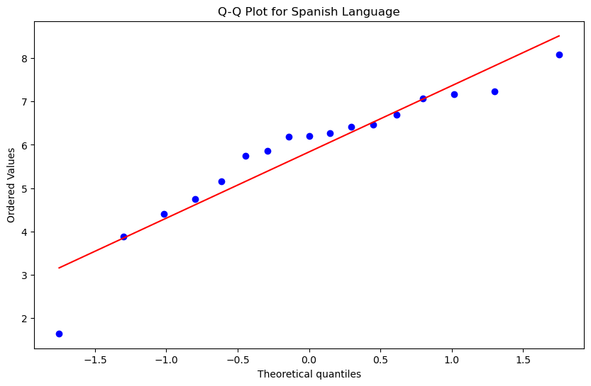

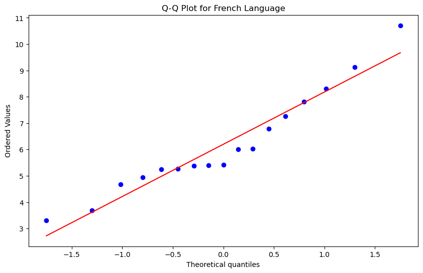

```python
# Q-Q plots per language
languages = new_page_df['language_preferred'].unique()
for lang in languages:
    stats.probplot(new_page_df[new_page_df['language_preferred']==lang]['time_spent_on_the_page'], dist="norm", plot=plt)
    plt.title(f"Q-Q Plot for {lang} Language")
    plt.show()
```

**Normality Check**

```python
# Shapiro-Wilk test for each group
for lang in ['English', 'French', 'Spanish']:
    data = new_page_df[new_page_df['language_preferred'] == lang]['time_spent_on_the_page']
    stat, p_val = stats.shapiro(data)
    print(f"Shapiro test for {lang}: p-value = {p_val:.4f}")
```

```
Shapiro test for English: p-value = 0.8863
Shapiro test for French: p-value = 0.3214
Shapiro test for Spanish: p-value = 0.0901
```

🧐 All groups shows normal distribution

**Homogeneity of Variances**

```python
# Levene's test
stat, p_val = stats.levene(
    new_page_df[new_page_df['language_preferred'] == 'English']['time_spent_on_the_page'],
    new_page_df[new_page_df['language_preferred'] == 'French']['time_spent_on_the_page'],
    new_page_df[new_page_df['language_preferred'] == 'Spanish']['time_spent_on_the_page']
)
print(f"Levene's test p-value: {p_val:.4f}")
```

```
Levene's test p-value: 0.4671
```

🧐 p-value = 0.4671 > 0.05, indicating equal variances across groups

**Final Test Selection/Statistics Decision:**

1. Normality: ✓ (all groups normal)
2. Equal Variances: ✓ (Levene's test p > 0.05)
3. Independence: ✓ (assumed from data collection)

Therefore, we will use **One-way ANOVA** because:

- All assumptions are met
- Most powerful test for comparing means of 3+ groups
- Standard ANOVA (not Welch's) as variances are equal

#### **Step 4: Execute Test** ✅

```python
# Define significance level
alpha = 0.05

# Prepare data for each language group
eng_times = new_page_df[new_page_df['language_preferred'] == 'English']['time_spent_on_the_page']
fr_times = new_page_df[new_page_df['language_preferred'] == 'French']['time_spent_on_the_page']
sp_times = new_page_df[new_page_df['language_preferred'] == 'Spanish']['time_spent_on_the_page']

# Conduct one-way ANOVA
f_stat, p_value = stats.f_oneway(eng_times, fr_times, sp_times)

print(f"F-statistic: {f_stat:.4f}")
print(f"p-value: {p_value:.4f}")
```

```
F-statistic: 0.8544
p-value: 0.4320
```

#### **Interpretation** ✅

**Statistical Interpretation:**

- F-statistic = 0.8544
- p-value = 0.4320 > α (0.05)
- Decision: Fail to reject the null hypothesis

**Technical Analysis** (for us):

- No significant differences found (p > 0.05)
- There is no significant difference in mean time spent on the new page across English, French, and Spanish users.

**Business Interpretation** (for notebook):

1. The time spent on the new page is statistically similar across all language versions
2. The new page design appears to be equally engaging regardless of language preference
3. No need for language-specific modifications to improve engagement time

**💡 Business takeaway:**

- Engagement on the new landing page is consistent across language groups.
- Efforts to increase time spent can focus on overall page improvements, rather than language-specific design changes.

# 🧐 Key Insights & Business Recommendations

**Key Findings from Analysis:**

1. **Time Spent Analysis**:
   - New page significantly increases engagement (6.2 vs 4.5 minutes)
   - More consistent user behavior on new page (less variation)
   - Minimum engagement increased from 0.2 to 1.7 minutes
2. **Conversion Rate Impact**:
   - Significant improvement in conversion (66% vs 42%)
   - 24 percentage point increase in conversion rate
   - Strong statistical evidence (p < 0.01)
3. **Language Analysis**:
   - No significant dependency between language and conversion
   - Time spent is consistent across all languages
   - Design works equally well for all language versions

**Business Recommendations:**

1. **Implementation Decision**:
   - Strongly recommend implementing the new page design
   - Clear evidence of improved user engagement and conversion
2. **Design Effectiveness**:
   - Keep the elements that increased minimum engagement time
   - Maintain the features that led to more consistent user behavior
3. **Language Considerations**:
   - No need for language-specific design modifications
   - Continue providing multilingual support as current implementation is effective

**Suggestions**

- Adopt the new landing page design permanently to capitalize on higher engagement and conversion.
- Focus on engagement-driven strategies (highlight key content, interactive elements) since higher time spent leads to higher conversions.
- Monitor post-launch metrics to ensure the conversion uplift is sustained at scale.
- A/B testing future changes: continue testing specific elements (e.g., call-to-action buttons, content layout) to further optimize conversions.